# Reproducible Research Assignment 1

Kashyap Kadam

4/1/2018

### Code for reading in the dataset and/or processing the data

```r
temp <- tempfile()
download.file("https://d396qusza40orc.cloudfront.net/repdata%2Fdata%2Factivity.zip", temp, mode="wb")
data <- unz(temp, "activity.csv")
activity <- read.csv(data, sep=",", header=T)
activity$date <- as.Date(activity$date)
```

### Histogram of the total number of steps taken each day

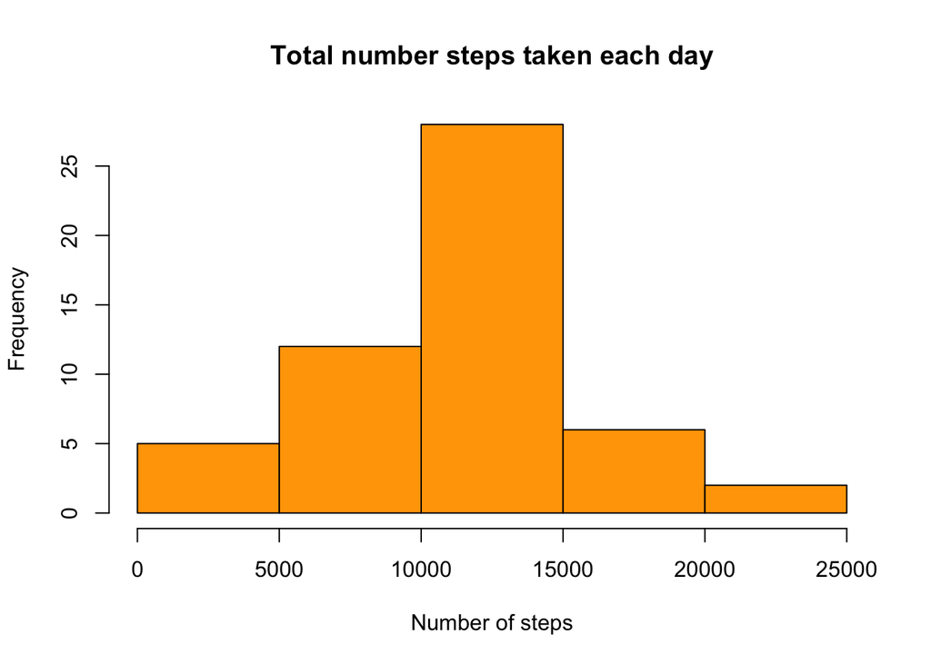

```r
stepsEachDay <- aggregate(steps ~ date, activity, sum, na.rm = TRUE)
hist(stepsEachDay$steps, col = "orange", main = "Total number steps taken each day", xlab = "Number of steps")
```

```r
meanSteps <- mean(stepsEachDay$steps, na.rm = TRUE)
medianSteps <- median(stepsEachDay$steps, na.rm = TRUE)
```

### Time series plot of the average number of steps taken

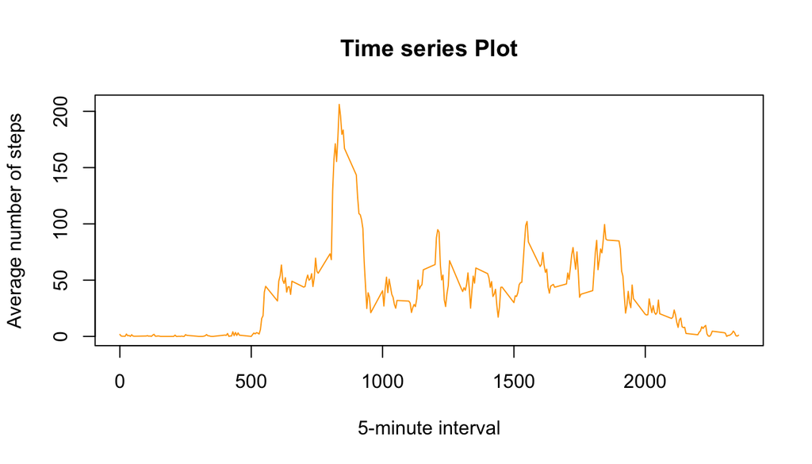

```r
averageActivity <- aggregate(steps ~ interval, activity, mean, na.rm = TRUE)
plot(averageActivity$interval, averageActivity$steps, col= "orange",  type = "l", xlab = "5-minute interval", ylab = "Average number of steps", main = "Time series Plot" )
```

### The 5-minute interval that, on average, contains the maximum number of steps

```r
maxInterval <- averageActivity$interval[[which.max(averageActivity$steps)]]
```

The 5-minute interval corresponding to maximum number of steps, on average across all days in dataset 835

### Code to describe and show a strategy for imputing missing data

```r
totalNA <- sum((is.na(activity$steps) | is.na(activity$date) | is.na(activity$interval)))
```

The total number of missing values in the dataset 2304

#### Create a new dataset that is equal to the original dataset but with the missing data filled in.

```r
stepsFillNA <- rep(0, 17568)
activityFillNA <- activity
cbind(activityFillNA, stepsFillNA)
MeanStepsPerInterval <- aggregate(steps ~ interval, data = activityFillNA, mean, na.rm=TRUE)
for (i in 1:nrow(activityFillNA))
{
        if (is.na(activityFillNA$steps[i]))
        {
           interval_pointer <- activityFillNA$interval[i]
                        for (j in 1:nrow(MeanStepsPerInterval))
                        {
                                if(MeanStepsPerInterval$interval[j] == interval_pointer) {
                                 activityFillNA$stepsFillNA[i] <- (MeanStepsPerInterval$steps[j])
                                }

                        }

        }
        else {
                activityFillNA$stepsFillNA[i] <- activityFillNA$steps[i]
        }
}
```

### Histogram of the total number of steps taken each day after missing values are imputed

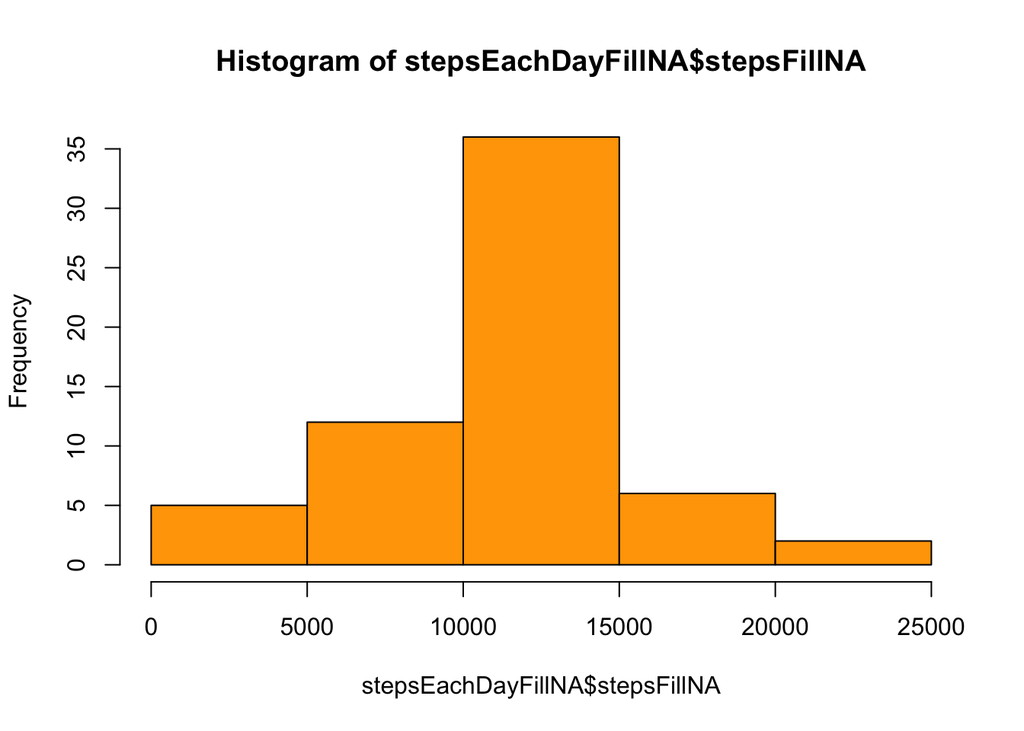

```r
stepsEachDayFillNA <- aggregate(stepsFillNA ~ date, activityFillNA, sum, na.rm = TRUE)
hist(stepsEachDayFillNA$stepsFillNA, col= "orange")
```

```r
meanStepsFillNA <- mean(stepsEachDayFillNA$stepsFillNA)
medianStepsFillNA <- median(stepsEachDayFillNA$stepsFillNA)
```

#### Create a new factor variable in the dataset with two levels – “weekday” and “weekend” indicating whether a given date is a weekday or weekend day.

```r
activityFillNA$day <- weekdays(as.Date(activityFillNA$date))
for (i in 1:nrow(activityFillNA)) {
        if (activityFillNA$day[i] == "Saturday") {
                activityFillNA$day[i] = "Weekend"
        }
        else if(activityFillNA$day[i] == "Sunday") {
                activityFillNA$day[i] = "Weekend"
        }
        else {
                activityFillNA$day[i] = "Weekday"
        }
}
activityFillNA$day <- as.factor(activityFillNA$day)
```

### Panel plot comparing the average number of steps taken per 5-minute interval across weekdays and weekends

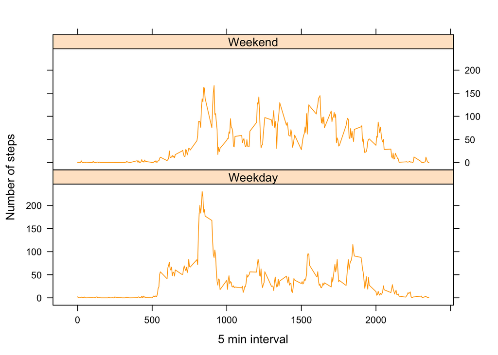

```r
library(lattice)
avg_steps_days <- aggregate(stepsFillNA ~ interval + day, activityFillNA, mean)
xyplot(stepsFillNA ~ interval| day ,data = avg_steps_days, col= "orange", layout=(c(1,2)),type="l",xlab="5 min interval", ylab="Number of steps")
```